# Computational Statistics 13.3: Support Vector Machines

## Support Vector Machines

### Overview

This lesson introduces Support Vector Machines.

### Objectives

After completing this module, students should be able to:

1. Explain the geometry of how SVM’s use hyperplanes to classify data.
2. Use an SVM to fit data with binary dependent variables.
3. Test an SVM out-of-sample.

### Readings

Recommended: James et al, [An Introduction to Statistical Learning](http://www-bcf.usc.edu/~gareth/ISL/ISLR%20Fourth%20Printing.pdf), Chapter 9.1-9.2

## Binary predictions

- As with logistic regression, we need slightly different methods for predicting binary variables when we have lots of independent variables.
- We could actually use our existing logit methods with a shrinkage aspect as per our previous lesson, but the machine learning community has already developed a large number of methods designed specifically for categorical prediction.
- This turns out to be an important class of problem – is a picture of a cat or a dog; will a customer like this movie or not; will the youtube user watch another video or not; etc – and thus decades of work have been dedicated to building better models for making binary decisions. Some with less than ideal consequences when used without a deep undestanding of causal relations.
- One of the fastest and most effective of this methods is the *support vector machine* (SVM), which was originally designed for simple binary classification with good out-of-sample predictive results, though it has since been extended to multiple categories and many other domains. For this course, we’ll simply introduce the binary case.

### The SVM

The fundamental idea behind a SVM can be illustrated using our clustering example from the previous module.

- Imagine the data plotted comprise three variables: the x1 value (horizontal axis), the x2 value (vertical axis), and the y value, which is a 1 or a 0.
- Observations where y=1 are plotted in blue, and observations where y=0 are plotted in red.
- The question is, if we were given a new data point, would we classify it as a 0 or a 1? How would we decide?

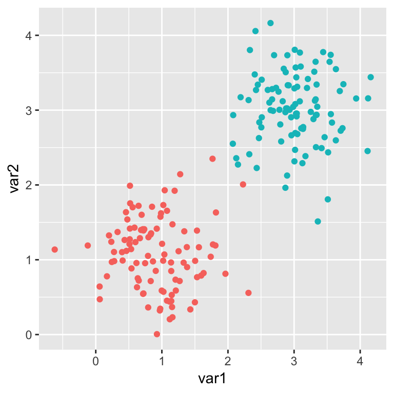

- Well, the obvious answer is that if that point was closer to the centroid of the blue cluster, we would guess that point was a 1, and if it was closer to the centroid of the red cluster, we would guess it to be a 0.
- This is equivalent to saying that if it falls on one side of the line between the two clusters, it’s a 1, and vice versa if it’s on the other side:

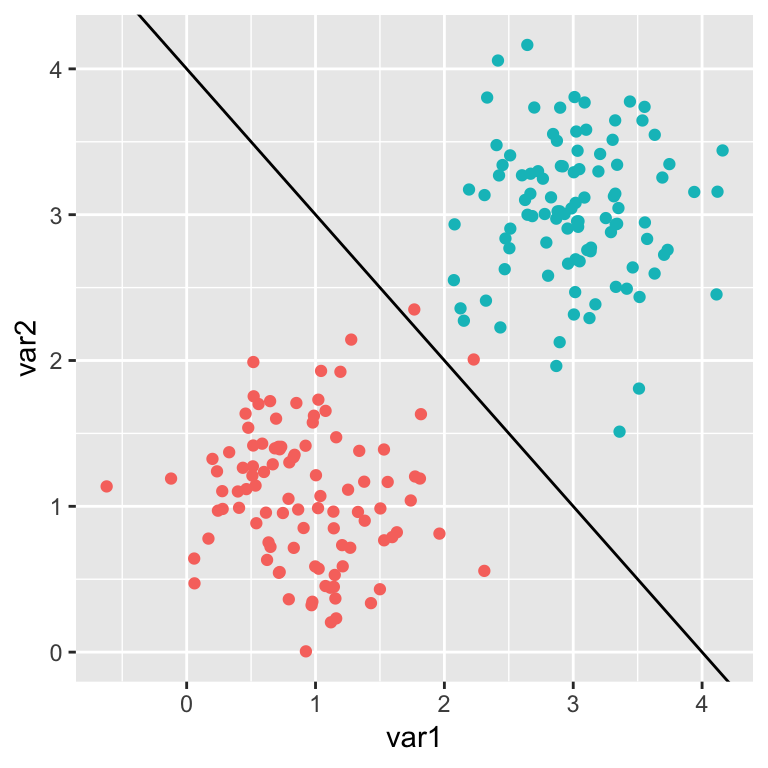

- An SVM is just a method for finding this best line given the X variables and a binary Y variable.

### Hyperplanes

- In more than 2 dimensions (ie, with more than two independent variables), the dividing line is actually a “hyperplane”.
- If you visualize points in three dimensions clustered into two groups, you can see that the divider separating points closer to cluster 1 vs those closer to cluster 2 is a flat 2-dimensional plane, rather than the 1-dimensional line from our previous example.
- And this continues: if the data are $k$ dimensional, the separating “hyperplane” is $k-1$ dimensional.
- This may sound complicated, but it’s actually algebraically identical to what we were doing with multiple regression.
- The equation for Y in a multiple regression is actually a hyperplane, for example one in three dimensions:

$$Y = \beta_0 + \beta_1 X_1 + \beta_2 X_2 + \beta_3 X_3$$

- We can’t visualize it, but that doesn’t matter as long as you have the core idea.

### Hyperplanes continued

- In the SVM, if our binary data are in $k$ dimensions, the plane separating them is just:

$$\beta_0 + \beta_1 X_1 + ... + \beta_p X_p$$

- Of course, these $\beta$ coefficients will *not* be the same as the ones you get regressing Y on the X variables!
- The job of the SVM is to find the best $\beta$ coefficients that define the plane that best separates the Y=1 points from the Y=0 points.
- The SVM differs from the cluster centroid approach defined above by how it defines “best”. The SVM defines the best plane as that plane which is farthest from our data.
- That is, there are a lot (infinte number) of planes that will separate our two clusters and the SVM chooses that plane which is farthest from the data: that is, the one with the largest distance to the closest data point.

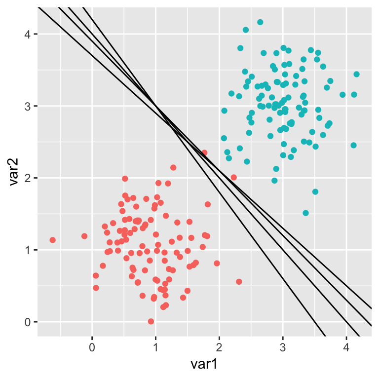

### Challenge

It turns out this method works remarkably well for out-of-sample prediction, much better than just using the plane defined by the midway point between the two centroids. However:

- In many cases the two sets of data are not nearly so well separated – in fact, if you imagine those two clusters closer together, there will often not be any line that cleanly separates the two groups.
- In fact, in the real world, this is almost always the case, and we have to just choose the plane that does the best job we can in separating the two classes of points.

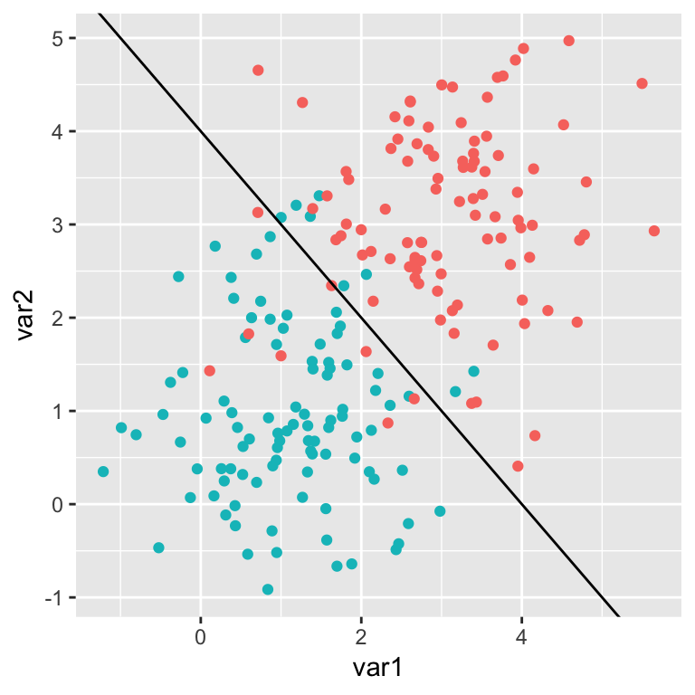

### Choosing the best results

- Like the shrinkage approaches, the SVM has a parameter we can tune to maximize ou-of-sample performancem,
- That parameter (often denoted $\gamma$ or $C$) is how tolerant is the model to data points being on the wrong side of the classification line.
- Some points wrong is often inevitable, but there is a **tradeoff**:
  - a low tolerance level means you try to find the plane with the least amount of mis-classifications;
  - a higher tolerance level means you find a plane with maybe more mis-classifications, but which may do a better overall job of keeping the bulk of the 1’s on one side and a bulk of the 0’s on the other.
- The details of how we find this plane given a set tolerance level go beyond what we will cover here, but are well described in [An Introduction to Statistical Learning](http://www-bcf.usc.edu/~gareth/ISL/ISLR%20Fourth%20Printing.pdf), sections 9.1 and 9.2.

## SVM example

We run the SVM method in `R` using the `svm` function in the inexplicably-named `e1071` package. For `svm` to work properly, the $y$ varaible must be a factor.

Then we run the svm specifying the dependent variable and independent variables (`y~.` just means y as function of all the others; this is a general shortcut you can use for lm and many other models), the cost $C$ or misclassification penalty, and a “kernel,” which we return to shortly.

```r
#install.packages("e1071")
#install.packages ("gridExtra")
library(e1071)
# Simulating data
x1 <- rnorm(100,1,1)
y1 <- rnorm(100,1,1)
x2 <- rnorm(100,3,1)
y2 <- rnorm(100,3,1)
factor <- as.factor(c(rep("1",100),rep("0",100)))
simdat <- data.frame(var1=c(x1,x2),var2=c(y1,y2),y=factor)

svmfit <- svm(y~., data=simdat, cost=10, kernel="linear")
summary(svmfit)
```

```
Call:
svm(formula = y ~ ., data = simdat, cost = 10, kernel = "linear")


Parameters:
   SVM-Type:  C-classification
 SVM-Kernel:  linear
       cost:  10

Number of Support Vectors:  54

 ( 27 27 )


Number of Classes:  2

Levels:
 0 1
```

### Plot the output

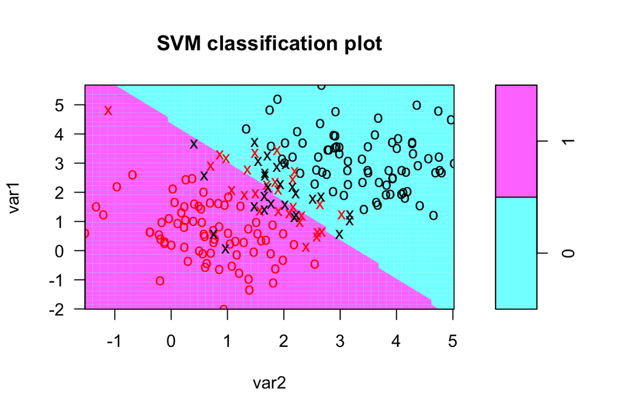

```r
plot(svmfit,simdat)
```

## Example Predictions

**How do we chose our cost C?**

- We want the best out-of-sample accuracy to make sure we aren’t over-fitting the model on arbitrary aspects of our sample.
- So as we did with `cv.glmnet`, we want to test a variety of cost levels using cross-validation: divide the sample into $k$ folds, fit the model at a bunch of different cost levels on the in-sample, and test on the out-sample; then chose the cost level that produces the most accurate fit out-of-sample.

### Example 1

- We do this using the `tune()` function that’s part of the `e1071` package, which is very much like the `cv.glmnet` function, and by default runs 10-fold cross-validation internally.

```r
costvalues <- 10^seq(-3,2,1)
tuned.svm <- tune(svm, y~., data=simdat, ranges=list(cost=costvalues), kernel="linear")
summary(tuned.svm)
```

```
Parameter tuning of 'svm':

- sampling method: 10-fold cross validation

- best parameters:
 cost
   10

- best performance: 0.11

- Detailed performance results:
   cost error dispersion
1 1e-03 0.475 0.21376259
2 1e-02 0.125 0.04249183
3 1e-01 0.130 0.05374838
4 1e+00 0.120 0.05868939
5 1e+01 0.110 0.03944053
6 1e+02 0.115 0.04743416
```

**Interpretation:**

### Example 2

Let us again use the Hitters baseball dataset as a test example, but this time, let’s turn Y into a binary, equal to 1 if the player earns more than $500K a year, and 0 if not.

### Example 2a

```r
y <- ifelse(Hitters$Salary > 500,1,0)
summary(y)
```

```
   Min. 1st Qu.  Median    Mean 3rd Qu.    Max.
 0.0000  0.0000  0.0000  0.4259  1.0000  1.0000
```

**Interpretation:**

- Note that only about 43% of players earn that much, at least in the era of this dataset.
- Thus if we were just in the game of predicting $y$ for any given player and we just blindly guessed that no, they do not earn more than $500K, we would get almost 58% of the players correct.
- So whatever our predictive successes are for SVM (or any other method), it has to be relative to that baseline, which is equivalent to our baseline guess of $\bar{y}$ in the continuous case.

```r
dat <- data.frame(x=x, y=as.factor(y))
tuned.svm <- tune(svm,y~., data=dat, ranges=list(cost=costvalues), kernel="linear")
summary(tuned.svm)
```

```
Parameter tuning of 'svm':

- sampling method: 10-fold cross validation

- best parameters:
 cost
   10

- best performance: 0.1863248

- Detailed performance results:
   cost     error dispersion
1 1e-03 0.3007123 0.12425313
2 1e-02 0.2018519 0.10609332
3 1e-01 0.2055556 0.10133904
4 1e+00 0.1903134 0.09912365
5 1e+01 0.1863248 0.11016922
6 1e+02 0.2015670 0.11564567
```

**Interpretation:**

### Example 2b

Let’s do a proper test: as in the previous lesson, we divide up our data into two halves, fit our model on one half, and then test it on the other.

```r
set.seed(1)
train <- sample (1:nrow(x),nrow(x)/2)
test <- (-train)
traindat <- dat[train,]
testdat <- dat[test,]
```

Now we fit the model on the training data:

```r
tuned.svm <- tune(svm,y~., data=traindat, ranges=list(cost=costvalues), kernel="linear")
```

And then predict y using the test data:

```r
yhat <- predict(tuned.svm$best.model,newdata=testdat)
table(predicted=yhat,truth=testdat$y)
```

```
         truth
predicted  0  1
        0 64 17
        1 13 38
```

**Interpretation:**

- The cross-validated `tune` output contains within it the best svm model under `$best.model` – we could also have just used `svmfit` as the direct output of `svm` using a pre-set cost, but this would not be as optimal as using the internal cross-validation to get the best cost level.
- The table above is called the **confusion matrix**, ie, the 1’s that were correctly predicted to be 1’s, the 1’s that were incorrectly predicted to be 0’s, and so forth. We can get the percentage correct with:

```r
sum(yhat==testdat$y)/length(testdat$y)
```

```
[1] 0.7727273
```

- This is not as well as we did purely in-sample, but that’s why out-of-sample testing is so rigorous and important.
- It means that if we over-fit the in-sample data, we are called out on it when we go out of sample.

### Better than guessing 0 for all?

The cross-validation of `tune()` might have led us to be a little over-optimistic about our model, but 77% is still much better than we would have gotten just by guessing 0 for everyone:

```r
sum(yhat==rep(0,length(testdat$y)))/length(testdat$y)
```

```
[1] 0.6136364
```

## Kernels

- One of the options in `svm` is the “kernel”, one of the major secrets of its success.
- It acts, effectively, to warp the space that our data exists in.
- Yep, sometimes a flat line or hyperplane is not the best way to divide two categories.
- The kernel of a SVM acts to bend the space before fitting the SVM, so that the hyperplane effectively becomes a curve, or many other different sorts of shapes.
- One of the most powerful of the kernels is the “radial” kernel, which curves the space.

### Radial kernel

Let’s test our model using the radial kernel:

```r
tuned.svm <- tune(svm,y~., data=traindat, ranges=list(cost=costvalues), kernel="radial")
yhat <- predict(tuned.svm$best.model,newdata=testdat)
sum(yhat==testdat$y)/length(testdat$y)
```

```
[1] 0.8787879
```

Much better! The SVM with the radial kernel (the default setting in R) is a very powerful binary modeling method.

### Compare with logistic regression

How about we compare the logistic regression, just as a baseline?

```r
logit.out <- glm(y~.,data=traindat,family = "binomial")
yhat.con <- predict(logit.out,newdata=testdat,type="response")
yhat <- round(yhat.con)
# Note how we use the "reponse" option to the get predicted probabilities,
#   and then we must round, so that any predicted prob > 0.5 is a 1, and vice versa for 0.
sum(yhat==testdat$y)/length(testdat$y)
```

```
[1] 0.780303
```

Not terrible – much better than just guessing 0, and about as well as the linear kernel SVM. But the radial kernel SVM is still much better.

### Which variables matter?

- One major drawback of the SVM though, particularly with the radial kernel, is that it makes it much harder to assess which variables are playing the largest role in allowing us to predict the dependent variable.
- While the logit may do worse, we can at least interpret the coefficients directly to see which variables are playing what role.
- There are of course ways of also doing this with the SVM (such as repeating the process with various variables omitted, or looking more closely at the support vectors), but they are trickier.
- **The tradeoff** is a common one: the logit predicts less well but is easier to interpet; the SVM is less interpretable, but predicts very well indeed.
- Again, we are just comparing the models in their ability to make predictions. Not test hypothesis or establish causality.
- And like the logit, the SVM can also be readily extended to dependent variables with more than two categories – but delving into that is beyond what we can cover here.